# Overview of R Package hdmax2

Basile Jumentier, Claire-Cécile Barrot, Olivier Francois, Johanna Lepeule

September 13, 2022

**Summary:**

This document presents a short overview and the main functions of the R package `hdmax2`.

## Introduction

- Step 1. **Evaluating associations between exposure, mediators and outcome** using latent factor mixed models (LFMMs) to estimate the effects of exposure $X$ on a matrix $M$ of CpG markers, and the effect of each marker on outcome, $Y$. The models can be described as follows

$$M=Xa^T +U_1V_1^T +E_1$$
where $a$ is the vector of effect sizes of exposure on DNAm levels, $U$ a matrix formed of $K$ latent factors estimated simultaneously with $a$, $V$ are loadings associated with the latent factors, and $E_1$ is a matrix of residual errors (EWAS 1),

$$Y=Xc+Mb^T +U_2V_2^T +E_2$$
where is $c$ the direct effect of exposure on outcome, $b$ the effect sizes of DNAm levels on outcome, $U_2$ the latent factors from a latent factor regression model, $V_2$ the corresponding loadings, and$E_2$ the a matrix of errors (EWAS 2).

- Step 2. **Identifying potential CpG mediators and aggregated mediator regions**. This step combines the significance values $P_x$ and $P_y$ obtained in EWAS 1 and 2 of step 1 to compute a single $P$-value for each CpG marker with the max squared function

## Starting with hdmax2

To install the latest version of **hdmax2**, use the github repository

```r
devtools::install_github("bcm-uga/hdmax2")
```

The hdmax2 package can be loaded as follows.

```r
library(hdmax2)
```

In this tutorial, we present an example of mediation analysis. The example file includes randomized human DNA methylation values, with simulated treatment (exposure), simulated phenotype (outcome), and simulated covariables.

```r
load("example_hdmax2.data")
```

## Evaluating associations between exposure, mediators and outcome

In order to estimate the number of latent factors in the LFMMs, we perform a principal component analysis (PCA) from the methylation matrix using the **prcomp** function as follows.

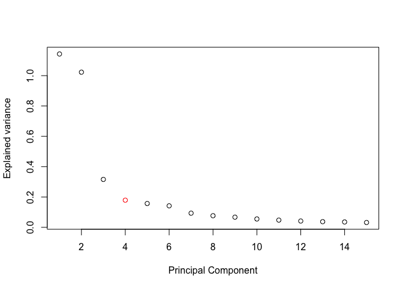

```r
pc <- prcomp(methylation)
plot(pc$sdev[1:15]^2,
     xlab = 'Principal Component',
     ylab = "Explained variance",
     col = c(rep(1, 3), 2, rep(1, 16)))
```

The screeplot indicates around 4 main components in the data. We will use $K = 4$ latent factors in subsequent analyses. The **mEWAS** function is then applied to estimate the effects of exposure $X$ on a matrix $M$ of CpG markers, and the effect of each marker on outcome $Y$. It uses some observed covariables ($conf$) and $K = 4$ latent factors.

```r
##Epigenome Wide Association Study with both exposure and outcome
res.mEWAQ <- mEWAS(X = exposure,
                   Y = phenotype,
                   M = methylation,
                   K = 4,
                   conf = covariables)
```

The function estimates the effects of $X$ and $Y$ on the matrix $M$. It also estimates the loadings for the four latent factors.

```r
##P-values of X and Y
pvalues <- res.mEWAQ$pValue

##scores matrix for the K latent factors
score_latent <- res.mEWAQ$U
```

The function **mEWAS** also computes the Genomic Inflation Factor (gif), which represents the deviation of the distribution of the observed test statistic compared to the distribution of the expected test statistic.

```r
##Genomic inflation factor for X and Y
res.mEWAQ$gif
```

```
#>        X        Y
#> 9.854444 0.912931
```

In case of highly stratified population (high gif), The gif is used to recalibrate $P$-values.

```r
##Calibrated P-values of X and Y
pvalues.cal <- res.mEWAQ$calibrated.pvalue

##Calibrated scores
score_latent.cal <- res.mEWAQ$calibrated.score2
```

## CpG mediators

**Identifying potential CpG mediators**

Combining the significance values $pvalues$ with the function **max2**. This test rejects the null-hypothesis that either the effect of exposure on DNAm or the effect of DNAm on outcome is null.

```r
cpg_max2 <- max2(pval1 = pvalues[, 1], pval2 = pvalues[, 2], diagnostic.plot = T)
```

The function **max2** computes a P-value and estimates a Q-value for every CpG. It quantifies the local false discovery rate (FDR) parameter eta0.

```r
##local FDR parameter
cpg_max2$eta0
```

```
#> [1] 0.6669741
```

In this example, we will consider FDR levels lower than 10%.

```r
##Selecting CpG
cpg <- cpg_max2$qval[cpg_max2$qval<= 0.1]
cpg
```

```
#> cg16619049 cg02896266 cg00582671 cg11132698 cg26003967 cg02635644 cg11144217
#> 0.09609973 0.03634804 0.05893670 0.08030833 0.07789091 0.09928920 0.09184869
#> cg13560058 cg23651812 cg09315878 cg27310827 cg02953397 cg15130241 cg02896318
#> 0.03634804 0.08697882 0.03634804 0.08494112 0.08612608 0.07954341 0.08465937
#> cg24492273
#> 0.09120212
```

**Quantifying indirect effects of single mediator**

The function **wrap_mediation** estimates the mediation effect sizes for each CpG.

```r
effect_cpg <- wrap_mediation(qval = cpg_max2$qval,
                            X = exposure,
                            Y = phenotype,
                            M = methylation,
                            U = res.mEWAQ$U,
                            sims = 100, FDR = 0.1)

##The parameter sims is the number of Monte Carlo draws for nonparametric bootstrap or quasi-Bayesian approximation. 10000 is recommended, but we used 100 for the example.
```

The average causal mediation effect (ACME) is the indirect effect. It also evaluates the average direct effect (ADE), the proportion mediated (PM), the total effect, and the regressions of X on M and M on Y.

```r
effect_cpg$ACME
```

```
#>            est       CI_2.5       CI_97.5 pval        CpG
#> 1  -0.05444921 -0.143564465 -0.0004251706 0.04 cg16619049
#> 2   0.10271715  0.013255951  0.2153562337 0.00 cg02896266
#> 3  -0.07544061 -0.164594744 -0.0151193486 0.02 cg00582671
#> 4  -0.10240486 -0.205277214 -0.0124026993 0.04 cg11132698
#> 5   0.06914878  0.005648141  0.1605853197 0.02 cg26003967
#> 6  -0.05957189 -0.143805441  0.0031866953 0.06 cg02635644
#> 7  -0.15651209 -0.291113712 -0.0221395212 0.00 cg11144217
#> 8   0.09713240  0.002881977  0.2235419488 0.06 cg13560058
#> 9  -0.05561361 -0.125576914 -0.0033163574 0.04 cg23651812
#> 10 -0.07641405 -0.175863515 -0.0080150280 0.00 cg09315878
#> 11 -0.16058581 -0.349612600 -0.0232993531 0.02 cg27310827
#> 12 -0.10676277 -0.202589017 -0.0045548397 0.04 cg02953397
#> 13 -0.10258076 -0.211743336 -0.0181692665 0.02 cg15130241
#> 14  0.07559329  0.003576948  0.1711714600 0.04 cg02896318
#> 15  0.05455921 -0.005655177  0.1429899336 0.08 cg24492273
```

## Identifying aggregated mediator regions (AMR)

**Identifying AMR**

The function **AMR_search** will identify aggregated methylated regions (AMR) using the max2 P-values. It computes the P-value and the FDR for each AMR.

```r
##Detecting AMR
res.amr_search <- AMR_search(chr = annotation$chr,
                   start = annotation$start,
                   end = annotation$end,
                   pval = cpg_max2$pval,
                   cpg = annotation$cpg)
res.amr_search$res
```

```
#>   chr   start     end            p          fdr
#> 2   1 1097041 1097281 3.918107e-05 0.0001175432
#> 3   1 1406967 1407016 4.520756e-03 0.0067811345
#> 1   1  955180  955181 9.885723e-02 0.0988572343
```

The function **AMR_build** builds a vector for each AMR, containing details for the AMR.

```r
res.arm_build <- AMR_build(res.amr_search, methylation = methylation, nb_cpg = 2)
##List of DMR
res.arm_build$res
```

```
#>    DMR chr   start     end            p          fdr nb
#> 1 DMR1   1 1097041 1097281 3.918107e-05 0.0001175432  3
```

```r
##CpG in the DMR
res.arm_build$CpG_for_each_AMR
```

```
#> $DMR1
#> [1] "cg06193359" "cg13560058" "cg00082285"
```

**Quantifying indirect effects**

The function **wrap_mediation_AMR** is similar to the function **wrap_mediation**.

```r
effect_amr <- wrap_mediation_AMR(X = exposure,
                            Y = phenotype,
                            AMR = res.arm_build$AMR_mean,
                            U = res.mEWAQ$U,
                            sims = 100)
```

```r
##Indirect effect
effect_amr$ACME
```

```
#>          est     CI_2.5   CI_97.5 pval  DMR
#> 1 0.06978554 0.01002472 0.1603501 0.04 DMR1
```

```r
##Direct effect
effect_amr$ADE
```

```
#>        est   CI_2.5  CI_97.5 pval  DMR
#> 1 3.821235 3.349011 4.366498    0 DMR1
```

```r
##Peoportion mediated
effect_amr$PM
```

```
#>          est      CI_2.5    CI_97.5 pval  DMR
#> 1 0.01602401 0.002420655 0.04250687 0.04 DMR1
```

```r
##Total effect
effect_amr$TE
```

```
#>       est CI_2.5 CI_97.5 pval  DMR
#> 1 3.89102      0 3.89102    0 DMR1
```

```r
##regressions of X on the DMR
effect_amr$xm
```

```
#>   Estimate   Std.Error  t.Value      pValue  CpG
#> 1 0.016411 0.005383184 3.048568 0.002422634 DMR1
```

```r
##regressions of the DMR on Y
effect_amr$my
```

```
#>   Estimate Std.Error  t.Value     pValue  CpG
#> 1 4.413889  2.087695 2.114241 0.03499613 DMR1
```